# Differential gene expression analysis of RNA sequencing data

# Introduction

Understanding and predicting cancer susceptibility is an important topic in medicine and biology, requiring knowledge of genes associated with disease development. One way to identify these genes is to compare gene expression data in cancer patients and healthy individuals. Some genes become more active (up-regulated), while others have decreased expression (down-regulated), leading to disruption of biological pathways<sup>1,2</sup>.

The data required for such an analysis is RNA-seq data (gene expression data), typically in a matrix where the rows represent genes and the columns represent samples. This matrix is also linked to a metadata table containing information about the experimental conditions or comparison groups. In the case of cancer research, this would be gene expression data in both tumor and normal (control) samples.

In this project, we will explore the GSE68086 dataset using unsupervised machine learning algorithms and find differentially expressed genes using the DESEq2 package.

GSE68086 dataset is available from several Internet resources.  
◦ [Expression Omnibus GEO platform](https://www.ncbi.nlm.nih.gov/geo/query/acc.cgi?acc=GSE68086).

There are two GSE68086 datasets on kaggle.com:  
◦ the [first](https://www.kaggle.com/datasets/willianoliveiragibin/gene-expression-v2) one contains counts and metadata in one file;  
◦ and the [second](https://www.kaggle.com/datasets/samiraalipour/gene-expression-omnibus-geo-dataset-gse68086) one includes 4 files with counts and metadata in txt and csv formats, and will be used in this analysis.  
There are also publications from ScienceDirect and Wiley on studies that used the GSE68086 dataset<sup>3–5</sup>.

A detailed information on sample preparation, RNA processing and quality control is available on the on the [NCBI](https://www.ncbi.nlm.nih.gov/geo/query/acc.cgi?acc=GSE68086) website. The RNA reads counts obtained from the high-throughput sequencing experiment, collected sample are blood platelets, included 55 samples from healthy individuals (HC, control group) and 228 samples from patients with six different malignant tumors: non-small cell lung cancer (lung), colorectal cancer (CRC), pancreatic cancer (pancreas), glioblastoma (GBM), breast cancer (breast) and hepatobiliary carcinomas (hepatobiliary). RNA reads were mapped to the hg19 reference genome (organism: Homo sapiens).

# Libraries

```r
library(here)
library(dplyr)     # data manipulation
library(tidyr)
library(stringr)

library(ggplot2)   # data visualization
library(pheatmap)  # heatmap plots
library(vsn)       # meanSdPlot()

library(gt)        # to make gt_table
library(patchwork) # combine multiple plots into a single layout

# Bioconductor packages:
library(sva)              # surrogate variable analysis
library(DESeq2)           # DE analysis
library(AnnotationDbi)    # annotation packages
library(org.Hs.eg.db)
```

# Load data and variables

```r
# Load metadata
metadata_processed <- readRDS(here::here("data/metadata_processed.rds"))

# Load counts matrix
counts_matrix <- readRDS(here::here("data/counts_matrix.rds"))

# A custom function summarizes the results for DE analysis and returns:
# - table with the top n differentially expressed genes;
# - summary and keywords;
# - ggplot for normalized counts.
source(here::here("scripts/functions/DEresults.R"))

# Settings for gt() function:
print_gt <- function(dat, table_title = "", rownames = FALSE){

  if(all(!class(dat) %in% c("data.frame"))){
    dat = as.data.frame(dat)
  }

  gt(dat, rownames_to_stub = rownames) %>%
    tab_header(table_title) %>%
    tab_options(table.align = "left",
                table.font.size = 12,
                table.font.names = "Helvetica",
                heading.title.font.size = 14,
                heading.align = "left",
                column_labels.padding.horizontal = 4,
                data_row.padding = 4,
                table.border.top.color = "white",
                table_body.hlines.color = "white",
                table.border.bottom.width = 0.6,
                column_labels.font.weight = "bold",
                column_labels.border.top.width = 0.6,
                column_labels.border.bottom.width = 0.6 )
}

# Colors for plots:
plot_colors  = list(
  batch = c("1" = "#6c8db1",  "2" =  "#b16c8a" ,"3" =  "#3CB371",
            "4" ="#87CEEB"  , "5" = "#FF8674" , "6" = "#ADFF2F"),

  mutational_subclass = c(HER2 = "#f7dc6f", wt = "#85929e",
                          Triple_Negative = "#6ca05d", HER2_PIK3CA = "#b7950b",
                          PIK3CA ="#db804f", KRAS = "#f941d7", MET = "#fbb7fb",
                          EGFR_MET ="#6c408c", EGFR =  "#c0f1ea",
                          KRAS_MET =   "#c7b9ff" ) ,

  cancer_type = c(breast = "#C11B17", hepatobiliary = "#5CB3FF",
                  CRC = "#a629f5", GBM = "#a7d170", lung = "#f78909",
                  pancreas = "#0711fe", HC = "#474747"))


# Labels for plots:
labels_ct = list(HC = "HC (control)",
                 breast = "breast",
                 CRC = "CRC",
                 GBM = "GBM",
                 hepatobiliary = "hepatobiliary",
                 lung = "lung",
                 pancreas ="pancreas" )

# Settings for ggplot.
## Fonts:
title_rel_size = 1
axis_rel_size = 0.9
legend_rel_size = 0.6

# Themes:
theme1 <- theme_light(base_size = 10,   base_family = "") +
  theme(plot.title = element_text(size = rel(title_rel_size)),
        axis.title = element_text( size = rel(axis_rel_size)) )

theme2 <- theme1 +
  theme(legend.key.spacing.y =  unit(0.05, 'cm'),
        legend.position = "bottom",
        legend.byrow = TRUE,
        legend.title = element_blank(),
        legend.text = element_text(size = rel(legend_rel_size))  )

theme3 <- theme_light(base_size = 10,   base_family = "") +
  theme(plot.title = element_text(size = rel(title_rel_size)),
        axis.title = element_text( size = rel(axis_rel_size)),
        axis.text.x = element_text(angle = 90),
        axis.title.x = element_blank(),
        legend.title = element_blank(),
        legend.text = element_text(size = rel(legend_rel_size)) )
```

# Exploratory data analysis

The source data contained 285 samples, but 2 samples were excluded due to low number of total reads counts.  
Preliminary metadata cleaning steps included:  
- extracting the cancer_type, batch, and mutational_subclass variables;  
- removing unwanted characters (such as -, +, quotes, etc.);  
- converting new variables into factors;  
- row names were also added and set to the same order as the column names of the counts data.

For the counts data the first non-numeric column was moved to the row names.

The processed data were saved as rds files: data/metadata_processed.rds and data/counts_matrix.rds.

## Counts data

counts_matrix contains RNA-seq count data for 57,736 genes and 283 samples.

```r
dim(counts_matrix)
```

```
## [1] 57736   283
```

The values in counts_matrix represent the counts of RNA sequencing reads corresponding to specific genes and proportional to gene expression in the sample; row names are Ensembl gene identifiers.

```r
# First 5 rows for first 5 samples
print_gt(counts_matrix[1:5, 1:5], rownames = TRUE)
```

|  | X3.Breast.Her2.ampl | X8.Breast.WT | X10.Breast.Her2.ampl | Breast.100 | X15.Breast.Her2.ampl |
| --- | --- | --- | --- | --- | --- |
| ENSG00000000003 | 0 | 0 | 0 | 0 | 17 |
| ENSG00000000005 | 0 | 0 | 0 | 0 | 0 |
| ENSG00000000419 | 44 | 14 | 16 | 8 | 9 |
| ENSG00000000457 | 26 | 1 | 14 | 0 | 4 |
| ENSG00000000460 | 81 | 98 | 18 | 17 | 0 |

The distribution of gene counts for the first sample shows that a large proportion of genes have zero or low reads counts. For better visualization, we also plot the distribution of non-zero counts on a logarithmic scale: a small proportion of genes have a very large number of reads (from thousands to hundreds of thousands).

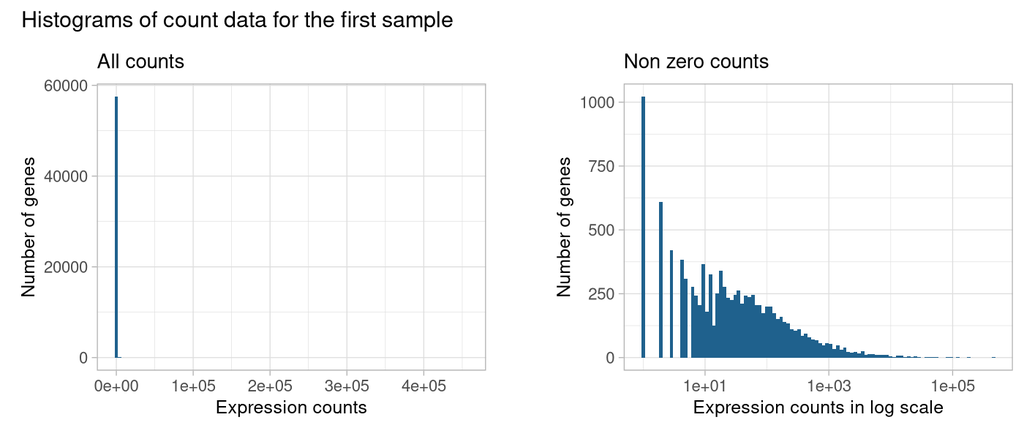

```r
# Histogram of the reads counts for 1 sample
p1 <- counts_matrix %>%
  dplyr::select(X3.Breast.Her2.ampl ) %>%
  ggplot(aes(x = X3.Breast.Her2.ampl  )) +
  geom_histogram(stat = "bin", bins = 100, fill = "#1f618d") +
  labs(x = "Expression counts", y = "Number of genes", title = "All counts") +
  theme1

# Histogram of the reads counts that are greater than 0 for sample 1;
# the number of reads is on a logarithmic scale
p2 <- counts_matrix %>%
  dplyr::select(X3.Breast.Her2.ampl ) %>%
  filter(X3.Breast.Her2.ampl >0) %>%
  ggplot(aes(x = X3.Breast.Her2.ampl  )) +
  geom_histogram(stat = "bin", bins = 100, fill = "#1f618d") +
  labs(x = "Expression counts in log scale", y = "Number of genes") +
  ggtitle("Non zero counts") +
  scale_x_log10() +
  theme1 + theme(plot.margin = margin(0, 0, 0, 30))

p1 + p2 +
  plot_annotation(title = "Histograms of count data for the first sample",
                  theme = theme(plot.title = element_text(size = rel(title_rel_size))))
```

## Metadata

In this analysis we use the processed data, metadata_processed, that has the factor variables:  
cancer_type (HC, breast, hepatobiliary, CRC, GBM, lung, pancreas);  
batch (1 2 3 4 5 6);  
mutational_subclass (EGFR, EGFR_MET, HER2, HER2_PIK3CA, KRAS, KRAS_MET, MET, PIK3CA, Triple_Negative, wt)  
The row names are the same as column names of the counts_matrix.

```r
# Metadata for the first five samples
print_gt(metadata_processed[1:5, ], rownames = TRUE)
```

|  | cancer_type | batch | mutational_subclass |
| --- | --- | --- | --- |
| X3.Breast.Her2.ampl | breast | 3 | HER2 |
| X8.Breast.WT | breast | 3 | wt |
| X10.Breast.Her2.ampl | breast | 3 | HER2 |
| Breast.100 | breast | 4 | Triple_Negative |
| X15.Breast.Her2.ampl | breast | 3 | HER2 |

The following bar charts show the distribution of values for the cancer_types variable, colored by mutation and batch. Each group contains more than 30 samples, except for hepatobiliary cancer.

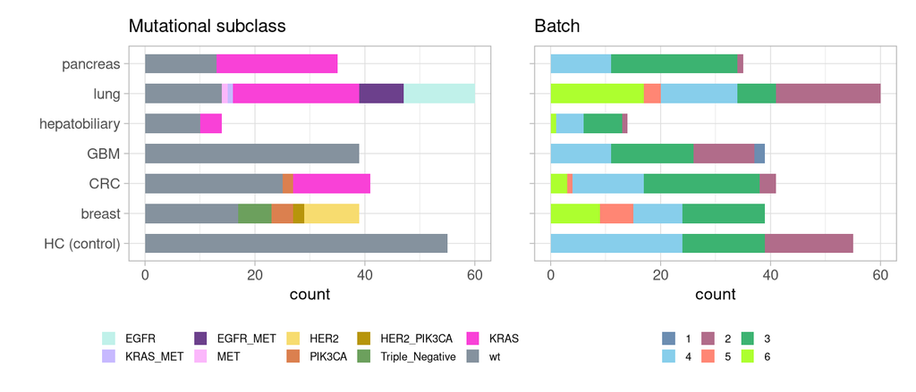

```r
# Bar plots of the  cancer types, colored by mutational subclass and batch
p1 <- metadata_processed %>%
  ggplot() +
  geom_bar(aes(y = cancer_type, fill = mutational_subclass), width = 0.65) +
  scale_fill_manual(values = plot_colors$mutational_subclass) +
  labs(title = "Mutational subclass", y = "") +
  scale_y_discrete(labels = labels_ct) +
  theme2 +
  theme(axis.text.y = element_text(size = 8), legend.key.size = unit(0.3, "cm"))

p2 <- metadata_processed %>%
  ggplot() +
  geom_bar(aes(y = cancer_type, fill = batch), width = 0.65) +
  scale_fill_manual(values = plot_colors$batch) +
  labs(title = "Batch", y = "") +
  theme2 +
  theme(axis.text.y = element_blank(), legend.key.size = unit(0.3, "cm"))

p1 + p2
```

## DESeqDataSet object

There are two main goals in this part of analysis: first, we need to find sources of variability in the data to account for it when performing DGE analysis; and second, we want to check if all samples are similar (correlated) within cancer_types groups to detect potential outliers.

To explore patterns in this data, we will use unsupervised learning methods.

The DESeqDataSetFromMatrix() function creates a DESeqDataSet object and brings together all the components needed for further analysis: the raw counts matrix, the metadata, and a design formula.

It is unlikely that there is no batch effect. But for now, we keep all the samples and set the design formula to cancer_types only.

```r
# Create DESeq2 object
dds <- DESeqDataSetFromMatrix(countData = counts_matrix,
                              colData = metadata_processed,
                              design = ~ cancer_type)
dds
```

```
## class: DESeqDataSet
## dim: 57736 283
## metadata(1): version
## assays(1): counts
## rownames(57736): ENSG00000000003 ENSG00000000005 ... ENSG00000273492
##   ENSG00000273493
## rowData names(0):
## colnames(283): X3.Breast.Her2.ampl X8.Breast.WT ... MGH.NSCLC.L59.TR522
##   MGH.NSCLC.L65.TR523
## colData names(3): cancer_type batch mutational_subclass
```

## Count normalization

The next step is to normalize the RNA-seq counts. This will make the data for different samples comparable despite different sequencing depths<sup>6,7</sup>. The estimateSizeFactors() function adds size factors to the DESeq2 object, which gives an estimate of the sequencing depth; the sizeFactors() function then allows access to the size factors.

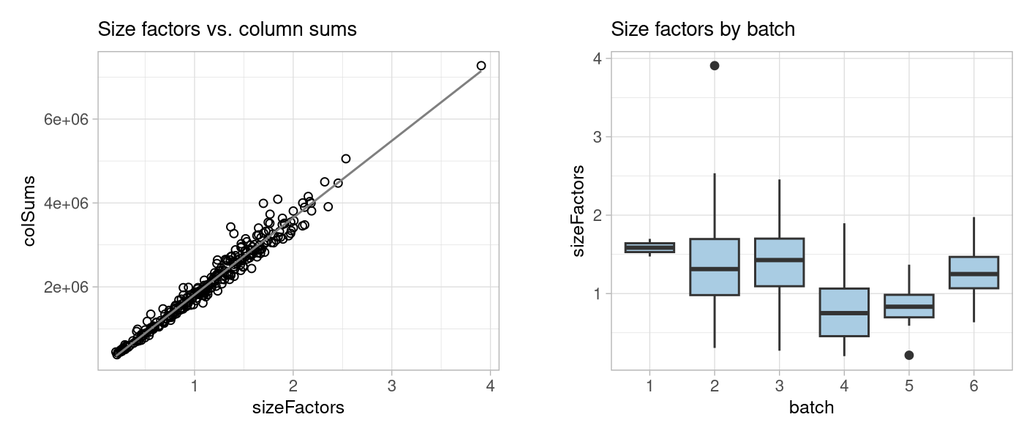

```r
dds <- estimateSizeFactors(dds)    # add size factors to  the DESeq2 object

# Data frame with size factors for each sample and total counts (column sums of
# the count data);  batch and sample name are added from the metadata
size_factors <- data.frame(size_factors = sizeFactors(dds),
                           col_sums = colSums(counts(dds)),
                           batch = metadata_processed$batch,
                           sample = rownames(metadata_processed))

# Scatterplot of size factors versus column sums
p1 <- ggplot(data = size_factors, aes(x = size_factors, y = col_sums)) +
  geom_point(size = 1.5, shape = 1) +
  geom_smooth(aes(x = size_factors, y = col_sums, colour = "lm"),
              method = lm, se = FALSE, linewidth = 0.5) +
  labs(x = "sizeFactors", y = "colSums", title = "Size factors vs. column sums") +
  scale_color_manual(values = plot_colors$batch) +
  theme1

# Boxplots of size factors stratified by batch variable
p2 <- ggplot(data = size_factors, aes(x = batch, y =  size_factors)) +
  geom_boxplot(fill = "#a9cce3") +
  labs(y = "sizeFactors", title = "Size factors by batch") +
  theme1 + theme(plot.margin = margin(0, 0, 0, 30))

p1 + p2
```

For this dataset, size factors range from 0.2 to 2.5, and one sample has a size factor of about 4, possibly due to the 6 batches and large number of samples.

```r
print_gt(size_factors[which.max(size_factors$size_factors), ])
```

| size_factors | col_sums | batch | sample |
| --- | --- | --- | --- |
| 3.907021 | 7273295 | 2 | Lung.0037 |

## Surrogate variable analysis (SVA)

To confirm the presence of the batch effect, we perform a surrogate variable analysis. SVA can be used to find hidden patterns in RNA-seq data and estimate surrogate variables. These surrogate variables can then be added to the model<sup>8</sup>. However, in this project, we will only use SVA to demonstrate the presence of the batch effect.  
We run SVA on the subset of the count matrix for genes with row means greater than 1.

```r
normalized_counts <- counts(dds, normalized = TRUE) # counts scaled by size factors

ind <- rowMeans(normalized_counts) > 1  # indices for genes with row means > 1

# Filter the matrix with normalized counts and keep genes with row average > 1
normalized_counts <- normalized_counts[ind, ]

# For SVA we build two models:
# model that includes condition of interest
model <- model.matrix(~cancer_type, colData(dds))

# model removes the condition of interest
model0 <- model.matrix(~1, colData(dds))

# estimate surrogate variables
svseq = svaseq(normalized_counts, model, model0, n.sv = 2)
```

The estimated surrogate variables are in the sv output of svaseq() function, and can be plotted and colored by batch and mutation subclass.

```r
# Output of the svaseq() function with two surrogate variables:
head(svseq$sv)
```

```
##              [,1]       [,2]
## [1,]  0.014202173 0.07502693
## [2,]  0.005343858 0.07482980
## [3,] -0.019610008 0.07245458
## [4,] -0.034454331 0.02796375
## [5,] -0.009168490 0.04915115
## [6,] -0.013566770 0.06289654
```

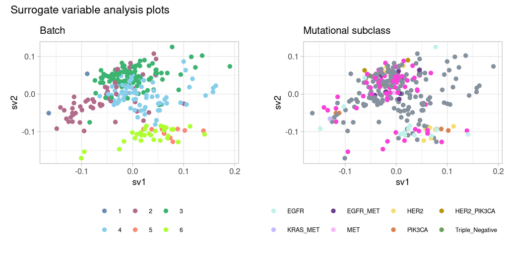

```r
# data for SVA plots:
sv = data.frame(sv1 = svseq$sv[ , 1],
                sv2 = svseq$sv[ , 2],
                batch = dds$batch,
                mutational_subclass = dds$mutational_subclass)

# SVA plot, colored by 'batch'
p1 <- ggplot(data = sv, aes(sv1, sv2, colour = batch)) +
  geom_point(aes(colour = batch)) +
  scale_color_manual(values = plot_colors$batch) +
  ggtitle("Batch") +
  theme2

# SVA plot, colored by 'mutational_subclass'
p2 <- ggplot(data = sv, aes(sv1, sv2, colour = batch)) +
  geom_point(aes(colour = mutational_subclass)) +
  scale_color_manual(values = plot_colors$mutational_subclass)  +
  ggtitle("Mutational subclass") +
  theme2 + theme(plot.margin = margin(0, 0, 0, 30))

p1 + p2 +
  plot_annotation(title = "Surrogate variable analysis plots",
                  theme = theme(plot.title = element_text(size = rel(title_rel_size))))
```

The graph on the left shows that batches 5 and 6 are different from the batches present in the control samples; batches 2, 3, and 4 overlap, but are still fairly distinct groups; and there are only two samples for batch 1, one of which is close to batch 3 and the other to batch 2.

The graph on the right shows that SVA did not detect any groups among the mutational subclasses: all mutations are mixed.

Given the presence of the batch effect, to conduct the DE analysis and to be able to compare the cancer groups with the control group, we leave only the batches included in the HC (control) cancer group, namely 2, 3 and 4. We also remove the sample with size factor of about 4.

```r
# indices for samples to be excluded from further analysis: sample with size
# factor 4 and samples from batches 1, 5 and 6
samples_rm <- c(rownames(size_factors[which.max(size_factors$size_factors), ]),
                rownames(size_factors[which(size_factors$batch %in% c("1", "5", "6")), ]) )

samples_rm <- which(rownames(metadata_processed) %in% samples_rm)

# Filter count matrix and metadata
counts_matrix <- counts_matrix[ , -samples_rm]
metadata_processed <- metadata_processed[ -samples_rm, ]

# Drop unused levels
metadata_processed$batch <- droplevels(metadata_processed$batch)
```

## Variance Stabilization

The variance of gene expression (reads counts) tends to increase with increasing mean expression level and may influence the results of PCA or clustering analyses. To address this issue, we also apply variance stabilizing transformations. The DESeq2 package has several functions that perform these types of transformations<sup>9</sup>.

The functions varianceStabilizingTransformation() and vst() (a wrapper for the first function) compute the variance stabilizing transformation with respect to library size. The sample with the maximum size factor was dropped as well as batches 1, 5 and 6, this should narrow the range of size factors.  
We will use vst() because it is faster to compute for 240 samples. For subsets, we will apply varianceStabilizingTransformation() function.

```r
# Create a new DESeq2 object using only samples for the batches 2,3 and 4;
# also add 'batch' to the design matrix
dds <- DESeqDataSetFromMatrix(countData = counts_matrix,
                              colData = metadata_processed,
                              design = ~ batch + cancer_type)

dds <- estimateSizeFactors(dds)    # add size factors to  the DESeq2 object;
                                   # does not required for VST functions
```

We also set ‘blind’ argument to FALSE.  
From function manual: if many of genes have large differences in counts due to the experimental design, it is important to set ‘blind = FALSE’ for downstream analysis.

```r
vsd <- vst(dds, blind = FALSE) # run variance stabilizing transformation

vsd_mat <- assay(vsd)          # and extract values

# The first 5 samples after VST:
print_gt(vsd_mat[1:5, 1:5], rownames = TRUE)
```

|  | X3.Breast.Her2.ampl | X8.Breast.WT | X10.Breast.Her2.ampl | Breast.100 | X15.Breast.Her2.ampl |
| --- | --- | --- | --- | --- | --- |
| ENSG00000000003 | 4.567436 | 4.567436 | 4.567436 | 4.567436 | 5.575468 |
| ENSG00000000005 | 4.567436 | 4.567436 | 4.567436 | 4.567436 | 4.567436 |
| ENSG00000000419 | 5.865803 | 5.351576 | 5.415179 | 5.638397 | 5.307749 |
| ENSG00000000457 | 5.578693 | 4.779405 | 5.361812 | 4.567436 | 5.063956 |
| ENSG00000000460 | 6.285737 | 6.516149 | 5.465048 | 6.092679 | 4.567436 |

The scatter plots of the first two samples show that after applying the variance stabilizing transformation, the variance of gene counts decreased for genes with larger gene counts.

On the Mean-Standard deviation plot the standard deviation for all samples reaches a plateau as the row mean increases.

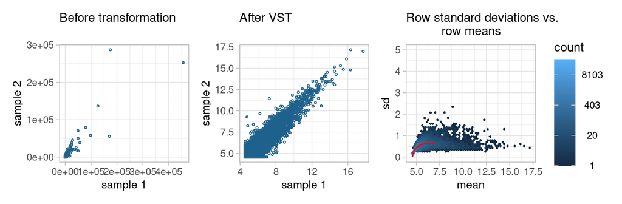

```r
# Scatter plots of the reads counts, Sample 1 vs Sample 2:
# before transformation
p1 <- ggplot(data = counts_matrix[ , 1:2],
            aes(x = X3.Breast.Her2.ampl, y = X8.Breast.WT )) +
  geom_point(size = 0.5, shape = 21, color = "#1f618d") +
  labs(x = "sample 1", y = "sample 2", title = "Before transformation") +
  theme1

# after VST
p2 <- ggplot(data = vsd_mat[ , 1:2],
             aes(x = X3.Breast.Her2.ampl, y = X8.Breast.WT )) +
  geom_point(size = 0.5, shape = 21, color = "#1f618d") +
  labs(x = "sample 1", y = "sample 2", title = "After VST") +
  theme1

# Create mean vs. standard deviation plot for vst() output
p3 <- meanSdPlot(vsd_mat, ranks = FALSE, plot = FALSE)

p3 <- p3$gg +
  ggtitle("Row standard deviations vs.
          row means") +
  ylim(c(0, 5)) +
  theme1

p1 + p2 + p3
```

## Correlation Heat map

We want to find samples that are less correlated (or less than a certain threshold) within their group (cancer type). A correlation heat map can give us an idea of how similar (or different) samples in a group are, and allows us to quickly spot outliers.  
First we will look at the HC samples (control group in cancer_types), all of which are wild type (mutation subclass is wt).

```r
cor_mat <- cor(vsd_mat)  # correlation matrix

# Indices for control samples
ind_HC <-  which(metadata_processed$cancer_type %in% c( "HC"))

cor_mat_HC = cor_mat[ind_HC, ind_HC]  # subset control samples
```

The heat map for control samples has column annotations with batch number.

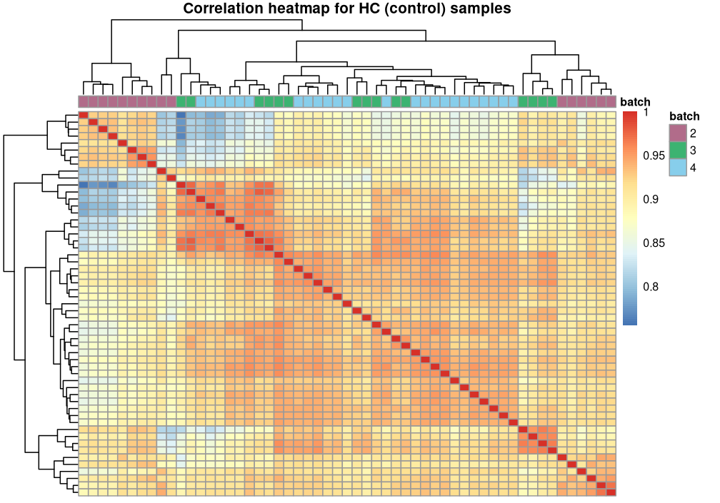

```r
# Create correlation heat map
cor_mat_HC %>%
  as.matrix() %>%
  pheatmap(annotation_col = dplyr::select(metadata_processed, batch),
           annotation_colors = list(batch = plot_colors$batch[c("2", "3","4")]),
           show_rownames = FALSE,
           show_colnames = FALSE,
           fontsize = 8,
           main = "Correlation heatmap for HC (control) samples")
```

Above, the SVA plot showed that about half of the samples from batch 2 are close to both batches 3 and 4, but there are many samples that form a group apart from the other batches.

In the heat map, the samples from batch 2 also formed two groups: one group is similar to almost all samples, and the other has a lower correlation with many samples.

Let’s find possible outliers: samples that have a correlation of less than 0.8 with 4 or more samples.

```r
# Find samples that are less correlated within HC cancer_type group
low_cor_ind = sapply(1:ncol(cor_mat_HC), function(j){
  sum(cor_mat_HC[ , j] < 0.8)
})

# Indices for samples that are less correlated with other samples in the HC group
ind_rm_HC = which(rownames(metadata_processed) %in%
                    colnames(cor_mat_HC)[which(low_cor_ind >= 4)])

# show these samples
print_gt(metadata_processed[ind_rm_HC, ], rownames = TRUE)
```

|  | cancer_type | batch | mutational_subclass |
| --- | --- | --- | --- |
| HD.45.1 | HC | 3 | wt |
| Control.3 | HC | 2 | wt |
| HD.38.2 | HC | 4 | wt |

Next we find outliers in the same way for each cancer type:

```r
# Levels of the variable cancer_type, except for "HC"
cancer_types = setdiff(as.character(unique(metadata_processed$cancer_type)), "HC")

# Find samples that are less correlated within their cancer_type group
low_cor <- sapply(cancer_types, function(i){
  ind = which(metadata_processed$cancer_type == i)   # indices for cancer_type i

  cor_mat_i = cor_mat[ind, ind]  # take a subset from the correlation matrix

  # number of samples with a correlation less than 0.8
  low_cor_ind = sapply(1:ncol(cor_mat_i), function(j){
    sum(cor_mat_i[ , j] < 0.8)
  })

  # get sample names for samples that have a correlation less than 0.8 with 4
  # or more samples.
  colnames(cor_mat_i)[which(low_cor_ind >= 4)]
})

low_cor
```

```
## $breast
## character(0)
##
## $hepatobiliary
## character(0)
##
## $CRC
## character(0)
##
## $GBM
## [1] "VU280.GBM" "VU418.GBM" "GBM.440"   "GBM.486"
##
## $lung
## [1] "Lung.0074.EGFR"
##
## $pancreas
## character(0)
```

```r
# Indices for samples to be excluded from further analysis
ind_rm = which(rownames(metadata_processed) %in%  c(unlist(low_cor)))
ind_rm = c(ind_rm, ind_rm_HC)
```

## Principal component analysis (PCA)

Finally, we can run the principal component analysis, and to make it simpler, we use the plotPCA() function and get the data for only the first two principal components.

The vast majority of genes have zero or low counts, therefore we perform PCA on a subset of genes with higher variance across the samples.

```r
# Indices for genes with higher variance:
ind_var <- sort(matrixStats::rowVars(vsd_mat[ , -c(ind_rm)]), decreasing = TRUE)[1:500]
ind_var <- which(rownames(counts_matrix) %in% names(ind_var))

vsd_sub <- vsd[ind_var , -ind_rm] # subset of the counts data after VST
```

The following lapply() function calculates PC1 and PC2 using the plotPCA() function for each batch (2 to 4).

```r
pca_batch <- lapply(c("2", "3", "4"), function(i){

  ind_batch = which(vsd_sub$batch  == i)  # indices for batch i

  # PC1 and PC2 data for the counts after variance stabilizing transformation
  suppressMessages({
    vsd_sub[, ind_batch] %>%
      DESeq2::plotPCA(intgroup = c("cancer_type", "mutational_subclass"),
                      pcsToUse = 1:2,
                      returnData = TRUE) %>%
      mutate(batch = i)
  })

}) %>% bind_rows()
```

From the PCA plots we see that KRAS and EGFR_MET form groups with some overlap, and wt is mixed with all mutations, just as all other mutations are mixed with KRAS.

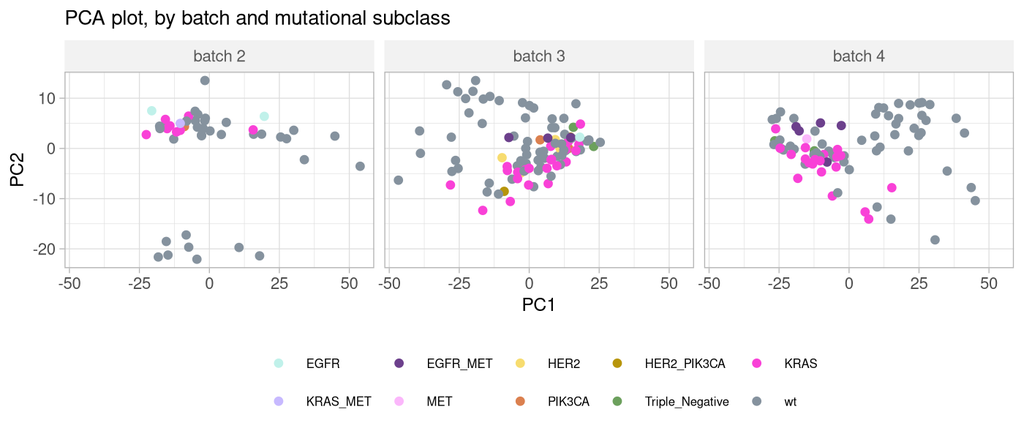

```r
# PCA plots faceted by batch and colored by mutational_subclass
ggplot(data =  pca_batch, aes(x = PC1, y = PC2, colour = mutational_subclass))+
  geom_point( size = 1.5) +
  scale_color_manual(values = plot_colors$mutational_subclass) +
  ggtitle("PCA plot, by batch and mutational subclass") +
  facet_grid(. ~ batch,
             labeller = as_labeller(c("2" = "batch 2", "3" = "batch 3", "4" = "batch 4")) ) +
  theme2 +
  theme(strip.background = element_rect(fill="gray95"),
        strip.text = element_text(colour = 'gray35'))
```

PCA analysis can separate the control samples (HC) from the cancer samples, but in batches 3 and 4, the GBM cancer group is close to or even mixed with the control samples, and in batch 2, the lung cancer group is slightly mixed with the control samples. Based on the PCA plots, similar gene profiles are likely to be observed between pancreatic cancer (pancreas), colorectal cancer (CRC), and breast cancer.

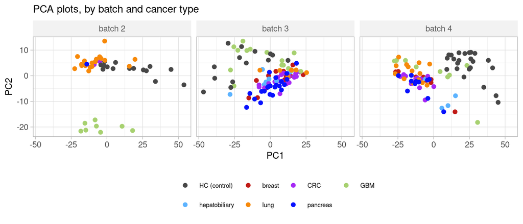

```r
# PCA plots faceted by batch and colored by cancer type
ggplot(data =  pca_batch, aes(x = PC1, y = PC2, colour = cancer_type))+
  geom_point( size = 1.5) +
  scale_color_manual(values = plot_colors$cancer_type,
                     labels = labels_ct) +
  ggtitle("PCA plots, by batch and cancer type") +
  facet_grid(. ~ batch,
             labeller = as_labeller(c("2" = "batch 2", "3" = "batch 3", "4" = "batch 4"))  ) +
  theme2 +
  theme(strip.background =element_rect(fill="gray95"),
        strip.text = element_text(colour = 'gray35'))
```

```r
# Remove less correlated samples from metadata and counts matrix
metadata_processed <- metadata_processed[-ind_rm, ]
counts_matrix <- counts_matrix[ , -ind_rm]
```

# Differential gene expression (DGE) analysis

GSE68086 is the large dataset, containing more than two groups to compare. One way is to use a subset for each cancer type and perform pairwise analyses. Another way is to use the DESeq2 package, which supports multi-factor designs, multi-level factors and experiments with many samples<sup>9,10</sup>.

For DGE analysis, we create a new DESeqDataSet using the filtered count matrix counts_matrix and the metadata table metadata_processed.

From PCA and SVA we know there is the batch effect, so we include it in our design formula, with cancer_type last since that is the variable we are interested in. We also include mutational_subclass even though PCA showed that all mutations are mixed with wt, but we see distinct groups of KRAS and EGFR_MET mutations.

```r
dds <- DESeqDataSetFromMatrix(countData = counts_matrix,  # create DESeqDataSet
                              colData = metadata_processed,
                              design = ~ batch + mutational_subclass + cancer_type)
```

The DESeq() function performs differential gene expression analysis. DESeq2 workflow also includes shrinkage of log2 fold changes to improve the accuracy needed for gene visualization and ranking. There are two ways: (1) run DESeq() and perform shrinkage afterwards using function lfcShrink() (2) another way is to set the ‘betaPrior’ argument to TRUE<sup>9</sup>.

```r
de <- DESeq(dds, betaPrior = TRUE )   #  Run analysis, ~5 min
```

The plot of dispersion estimates shows that dispersion decreases as the mean increases, and the raw dispersions follow the fitted line fairly well, indicating a reasonable fit of the data to the DESeq2 model.

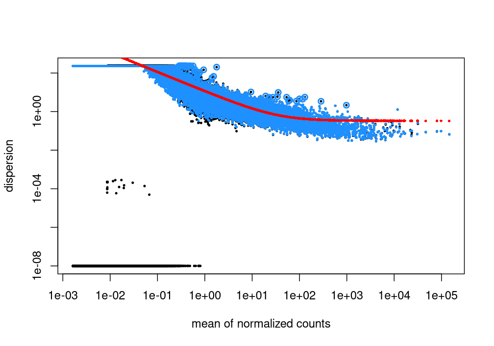

```r
plotDispEsts(de, cex = 0.5, legend = FALSE)   # plot the dispersion estimates
```

# Results

We first look at the results for one cancer type, CRC (contrast set to CRC and HC), and set alpha to 0.01 so that results for adjusted p-values less than 0.01 are colored in the MA and Volcano plots.

```r
res_CRC <- results(de,                            # extract results for CRC
                   contrast = c("cancer_type", "CRC", "HC"),
                   alpha = 0.01)
```

There are a lot more down-regulated genes (19%) than up-regulated (~2%)

```r
summary(res_CRC)
```

```
##
## out of 27524 with nonzero total read count
## adjusted p-value < 0.01
## LFC > 0 (up)       : 527, 1.9%
## LFC < 0 (down)     : 5239, 19%
## outliers [1]       : 20, 0.073%
## low counts [2]     : 14072, 51%
## (mean count < 0)
## [1] see 'cooksCutoff' argument of ?results
## [2] see 'independentFiltering' argument of ?results
```

## MA plot and Volcano plot

There are two types of graphs that visualize the log2 fold change in gene expression in one group of samples (cancer) compared to another (control). The MA plot is a scatterplot with the log2 fold changes on the y-axis and the mean of the normalized counts on the x-axis. The Volcano plot displays the log2 fold changes on the x-axis against statistical significance (p-values or adjusted p-values) on y-axis.

```r
p1 = DESeq2::plotMA(res_CRC, returnData = TRUE)  # data for MA plot

p1 = p1 %>%                    # ggplot for the for MS plot
  ggplot(aes(x = mean + 0.001, # add 0.001 to avoid infinite values
             y = lfc,
             color = isDE)) +
  geom_point(size = 0.8, alpha = 0.8) +
  # The DESeq2::plotMA() function displays the results in logarithmic scale,
  # but for the ggplot we need to add a logarithmic x-axis scale.
  scale_x_log10() +
  scale_color_manual(values = c("gray", "blue")) +
  guides(color = "none") +
  labs(x = "mean of normalized counts",
       y = "log fold change",
       title = "MA plot") +
  theme1

res_CRC <- res_CRC %>%       # data for Volcano plot
  as.data.frame() %>%
  mutate(threshold = padj < 0.01)

p2 <- res_CRC %>%            # ggplot for Volcano plot
  ggplot(aes(x = log2FoldChange,
             y = -log10(padj),
             color = threshold)) +
  geom_point(size = 0.8, alpha = 0.8) +
  labs(title = "Volcano plot",
       x = "log2 fold change",
       y = "-log10 adjusted p-value") +
  guides(color = "none") +
  scale_color_manual(values = c( "gray", "blue")) +
  theme1 + theme(plot.margin = margin(0, 0, 0, 30))
```

The MA and Volcano plots show this trend: there are more values with negative log fold change values corresponding to p-values less than 0.01.

If we check the relevant publications, we can find articles that report that more of differentially expressed genes are down-regulated in cancer cell samples; however, the difference is not as significant as in these data<sup>11,12</sup>.

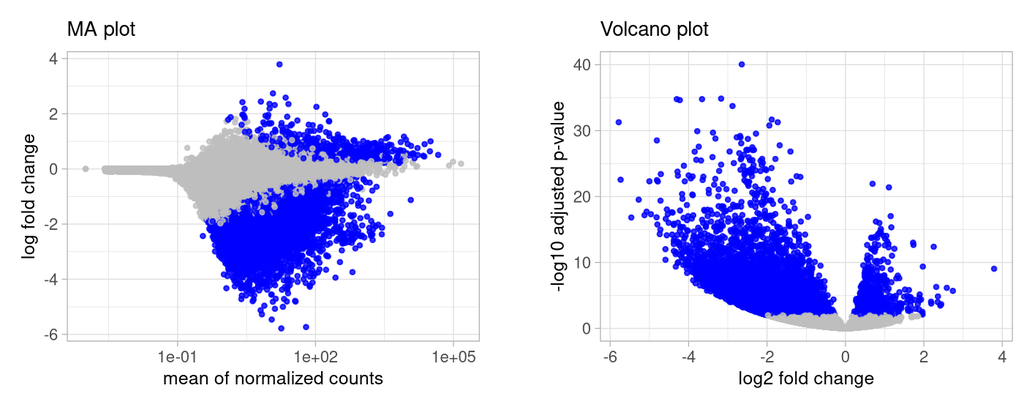

```r
p1 + p2
```

## Annotation

Adding the gene name and gene type can help to understand which types of genes are expressed differently and compare the results with literature data.

For this purpose, we use the org.Hs.eg.db package to add SYMBOL, GENENAME and GENETYPE to the results table with top 20 differently expressed genes, by ENSEMBL (Ensembl id). Hs.eg.db is an organism specific annotation package for Human genome.

We take results with adjusted p-values less than 0.01 and order them by the absolute value of the stat (Wald statistic), which is the log2FoldChange divided by lfcSE, to find results corresponding to larger log fold changes and smaller standard errors.

```r
# Add variable ENSEMBL which will be used to match records from org.Hs.eg.db
res_CRC$ENSEMBL <- rownames(res_CRC)

res_CRC <- res_CRC %>%       # results for top 20 differently expressed genes
  filter(padj < 0.01) %>%
  arrange(desc(abs(stat))) %>%
  slice_head(n = 20)

ensembl_ids = res_CRC$ENSEMBL     # Ensembl ids for top 20 genes

# Annotation data for Ensembl identifiers in res_CRC
ann_data <- AnnotationDbi::select(org.Hs.eg.db,
                                  keys = ensembl_ids,
                                  # columns from org.Hs.eg.db:
                                  columns = c("SYMBOL", "GENENAME", "GENETYPE" ),
                                  keytype = "ENSEMBL")
res_CRC <- res_CRC %>%    # add symbol, gene name and gene type to 'res_CRC'
  left_join(ann_data, by = "ENSEMBL")

res_CRC %>%                # show first 6 results
  dplyr::select(SYMBOL, GENENAME, GENETYPE, padj,
                baseMean, log2FoldChange, lfcSE, stat) %>%
  print_gt() %>%
  opt_interactive(page_size_default = 5)
```

| SYMBOL | GENENAME | GENETYPE | padj | baseMean | log2FoldChange | lfcSE | stat |
| --- | --- | --- | --- | --- | --- | --- | --- |
| SON | SON DNA and RNA binding protein | protein-coding | 8.92801044321289e-41 | 150.303996104718 | -2.64316038357493 | 0.187985419873731 | -14.0604541849593 |
| LUC7L3 | LUC7 like 3 pre-mRNA splicing factor | protein-coding | 1.38896033590848e-35 | 187.687610737059 | -3.17032303821253 | 0.24135976679093 | -13.1352589553947 |
| MALAT1 | metastasis associated lung adenocarcinoma transcript 1 | ncRNA | 1.67751818296864e-35 | 24.556151251201 | -4.30133286349706 | 0.32881701740041 | -13.0812355683502 |
| TRBC2 | T cell receptor beta constant 2 | other | 1.67751818296864e-35 | 169.477728101062 | -3.65697259539374 | 0.279834676350105 | -13.0683324993592 |
| ANKRD36 | ankyrin repeat domain 36 | protein-coding | 2.37434356542913e-35 | 75.1684848502895 | -4.22360443085439 | 0.324272704859502 | -13.0248533643446 |
| RPLP2 | ribosomal protein lateral stalk subunit P2 | protein-coding | 1.86359583318828e-34 | 734.843350886785 | -2.8802305103229 | 0.224098182481052 | -12.8525384652168 |
| FAU | FAU ubiquitin like and ribosomal protein S30 fusion | protein-coding | 2.14361620055288e-32 | 264.434955772443 | -1.87994647646138 | 0.150782623984324 | -12.4679251944629 |
| RPLP1 | ribosomal protein lateral stalk subunit P1 | protein-coding | 5.363211272871e-32 | 1319.51760238118 | -1.72596252068602 | 0.139461395888687 | -12.3759159994614 |
| CCR7 | C-C motif chemokine receptor 7 | protein-coding | 5.363211272871e-32 | 18.0331299076081 | -5.78229135689634 | 0.467276268919463 | -12.3744596965461 |
| RPS20 | ribosomal protein S20 | protein-coding | 1.66995485377242e-31 | 694.419224895119 | -1.94098362626483 | 0.158132653143427 | -12.274401192171 |

[output cut: 10 more lines]

Most of these genes are protein coding, and there are many ribosomal proteins.

```r
# Proportion of protein coding genes in the results table
sum(str_detect(res_CRC$GENETYPE, "protein-coding"), na.rm = TRUE)/length(res_CRC$GENETYPE)
```

```
## [1] 0.85
```

```r
# Proportion of genes in the results table encoding ribosomal proteins
sum(str_detect(res_CRC$GENENAME, "ribosomal"), na.rm = TRUE)/length(res_CRC$GENETYPE)
```

```
## [1] 0.4
```

## plotCounts

The plotCounts() function (DESeq2) plots the normalized counts for a single gene. We can look at one gene that is differentially expressed in CRC, but make a plot for all cancer types.

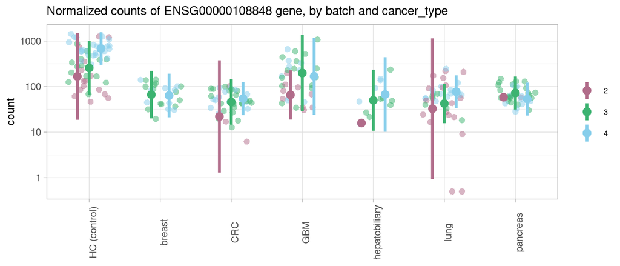

```r
ind <- res_CRC$ENSEMBL[2]    # index for one gene from the results table for CRC

plot_title <- paste("Normalized counts of ", ind, " gene, by batch and cancer_type" , sep = "")

# Plot  normalized counts for one gene for all groups in the cancer_type
# and color by batch
set.seed(1)
plotCounts(dds,
           ind,
           intgroup = "cancer_type",
           returnData = TRUE)  %>%
  bind_cols(batch = metadata_processed$batch,
            mutational_subclass = metadata_processed$mutational_subclass) %>%
  ggplot(aes(x = cancer_type, y = count, colour = batch)) +
  geom_jitter(width = 0.3, size = 2, shape = 16, alpha = 0.5) +
  stat_summary(fun.data = mean_sdl,
               position = position_dodge(width = 0.5),
               linewidth = 1.1) +
  # The plotCounts() function displays the results in logarithmic scale,
  # but for the ggplot we need to add a logarithmic y-axis scale.
  scale_y_log10() +
  scale_color_manual(values = plot_colors$batch) +
  scale_x_discrete(labels = labels_ct) +
  ggtitle(plot_title) + theme3
```

Overall, batch 2 has lower means and higher standard deviations. Batches 3 and 4 are more similar, however, in the PCA plot, batch 4 showed better separation of cancer types, so for further analysis we will focus on the results for samples from batch 4.

The following graph is a plot of normalized counts for the top 20 differentially expressed genes in CRC group (Ensembl identifiers have been replaced by gene symbols (SYMBOL)).

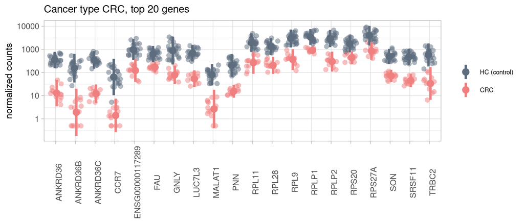

```r
# Get data using plotCounts() function for all 20 genes in the results table for CRC:
res_CRC_plot <- lapply(res_CRC$ENSEMBL, function(i){

  plotCounts(dds, i, intgroup = "cancer_type", returnData = TRUE)  %>%
    # add batch and mutational_subclass variables from metadata_processed:
    bind_cols(batch = metadata_processed$batch,
              mutational_subclass = metadata_processed$mutational_subclass) %>%
    filter(cancer_type %in% c( "CRC", "HC"), batch == "4") %>%
    mutate(ENSEMBL = i)

}) %>% bind_rows()

# Add Ensembl IDs:
res_CRC_plot <- res_CRC_plot %>%
  left_join(res_CRC[ , c("ENSEMBL", "SYMBOL")]) %>%
  mutate(SYMBOL = ifelse(is.na(SYMBOL), ENSEMBL , SYMBOL))

# Make a plot:
set.seed(1)
ggplot(res_CRC_plot, aes(x = SYMBOL , y = count, colour = cancer_type)) +
  geom_jitter(width = 0.3, size = 2, shape = 16, alpha = 0.5) +
  stat_summary(fun.data = mean_sdl,
               position = position_dodge(width = 0.2),
               linewidth = 1.1) +
  scale_y_log10() +
  scale_color_manual(values = c("#5d6d7e" , "#F08080" ),
                     labels = c("HC (control)", "CRC") ) +
  labs(x = "" , y = "normalized counts", title = "Cancer type CRC, top 20 genes") +
  theme3
```

We can compare these results with the available publications, keeping in mind that the GSE68086 RNA-seq data are obtained from blood samples, whereas many available publications typically study tumor tissue.

For example, RP genes (ribosomal proteins) are significantly down-regulated in CRC cancer samples for this dataset. There are studies showing increased expression of RP genes in CRC samples,<sup>13</sup> while other studies found that RP genes are down-regulated.<sup>14,15</sup>

```r
# A subset of the results table that includes only RP genes:
res_CRC %>%
  dplyr::select(log2FoldChange, SYMBOL, GENENAME) %>%
  arrange(SYMBOL) %>%
  filter(str_detect(SYMBOL, "RP")) %>%
  print_gt()
```

| log2FoldChange | SYMBOL | GENENAME |
| --- | --- | --- |
| -2.677004 | RPL11 | ribosomal protein L11 |
| -2.488056 | RPL28 | ribosomal protein L28 |
| -2.772603 | RPL9 | ribosomal protein L9 |
| -1.725963 | RPLP1 | ribosomal protein lateral stalk subunit P1 |
| -2.880231 | RPLP2 | ribosomal protein lateral stalk subunit P2 |
| -1.940984 | RPS20 | ribosomal protein S20 |
| -2.281599 | RPS27A | ribosomal protein S27a |

Even greater log-fold change in ANKR (ankyrin repeat domain) gene expression. And we can find articles reporting that ANKR (ankyrin repeat domain) mRNA expression is significantly lower in CRC tumor tissues than in control samples<sup>16</sup>.

```r
# A subset of the results table that includes only ankyrin genes:
res_CRC %>%
  dplyr::select(log2FoldChange, SYMBOL, GENENAME) %>%
  arrange(SYMBOL) %>%
  filter(str_detect(SYMBOL, "ANKR")) %>%
  print_gt()
```

| log2FoldChange | SYMBOL | GENENAME |
| --- | --- | --- |
| -4.223604 | ANKRD36 | ankyrin repeat domain 36 |
| -4.809747 | ANKRD36B | ankyrin repeat domain 36B |
| -3.778772 | ANKRD36C | ankyrin repeat domain 36C |

## DEresults

Now let’s look at other cancer types, but put the above code into a custom function DEresults(), that returns:  
- table with top n differentially expressed genes (genes with padj less than ‘alpha’ and ordered by ‘sort.by’ argument, which is “stat” or “padj” or “log2FoldChange”);  
- summary and keywords for these genes;  
- ggplot for normalized counts filtered for the specified batch (or all batches if ‘batch=NULL’).

The DEresults() function shows the results for all batches. It does not rerun the DESeq() function, but only retrieves the results. However, the data for the normalized values plot can be filtered using the ‘batch’ argument.

The lung cancer results also indicate that the vast majority of differentially expressed genes are down-regulated and protein coding.

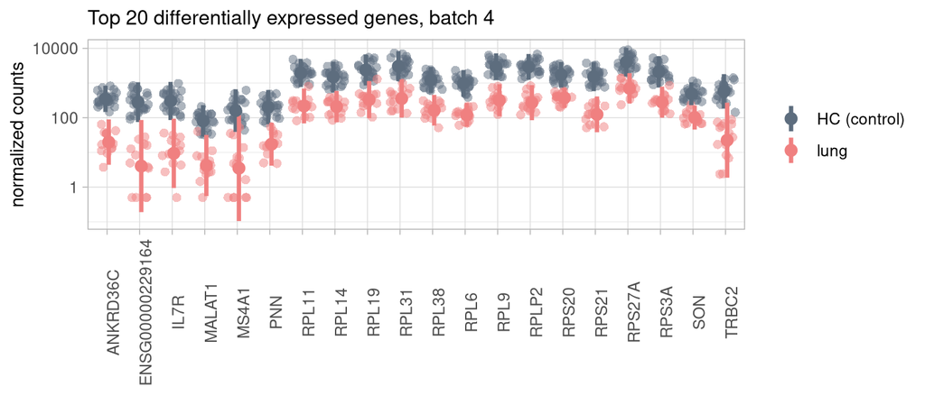

```r
# Get top 20 results for lung cancer type using custom function DEresults()
DEresults_lung <- DEresults(de = de,
                            md = metadata_processed ,
                            level.1 = "HC",     # contrast level 1 (control)
                            level.2 = "lung",   # contrast level 2
                            alpha = 0.01,       # cut off for padj
                            batch = 4,          # batch number or NULL
                            # sort results by "stat", "padj"  or "log2FoldChange"
                            sort.by = "stat",
                            n = 20              # number of results
                            )

DEresults_lung[[3]]  # normalized counts plot
```

```r
DEresults_lung[[2]]  # summary and keywords
```

[output not shown]

About 41% of the genes in GSE68086 do not have a corresponding GENETYPE in the org.Hs.eg.db database.

```r
# Data frame for all gene types corresponding to genes in the GSE68086 dataset
gene_types_all <- AnnotationDbi::select(org.Hs.eg.db,
                      keys = rownames(counts_matrix),
                      columns = "GENETYPE" ,
                      keytype = "ENSEMBL")  %>%
  # org.Hs.eg.db may have more than one row per Ensembl ID, so keep only
  # the first match.
  distinct(ENSEMBL, .keep_all = TRUE)

mean(is.na(gene_types_all$GENETYPE))  # proportion of the missing values
```

```
## [1] 0.4135202
```

But we can compare the distribution of the available gene types in the entire dataset and those genes that are differentially expressed. The org.Hs.eg.db contains about 55.8% protein-coding genes (shown in gray), while differentially expressed genes are mainly protein-coding genes: 85% for CRC samples and more than 90% for lung cancer samples (shown in blue).

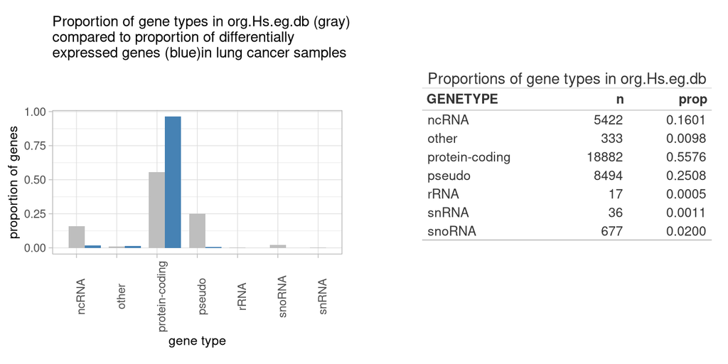

```r
# Drop NAs in 'gene_types_all' data frame and count gene types:
gene_types_all <- gene_types_all %>%
  drop_na() %>%
  group_by(GENETYPE) %>%
  summarise(n = n()) %>%
  ungroup() %>%
  mutate(prop = round(n/sum(n), 4))

# "DEresults_lung[[2]][[2]]" is a table that contains the number of gene types
# for genes with padj values less than 0.01 (alpha)
gene_types_de <- DEresults_lung[[2]][[2]] %>%
  # n is the number of gene types regardless of up or down regulation:
  mutate(n = up + down)

# Plot: proportions of gene types in org.Hs.eg.db and differentially expressed
# genes in lung cancer type
p1 <- ggplot(data = gene_types_all) +
  geom_col(aes(x = GENETYPE, y = n/sum(n)),
           fill = "gray", width = 0.4, just = 0.5) +
  geom_col(data = gene_types_de,
           aes(x = gene.type, y = n/sum(n)),
           fill = "steelblue", width = 0.4, just = -0.5) +
  labs(y = "proportion of genes", x = "gene type",
       title = "Proportion of gene types in org.Hs.eg.db (gray) \ncompared to proportion of differentially \nexpressed genes (blue)in lung cancer samples") +
  guides(fill = "none") +
  theme1 + theme(plot.margin = margin(0, 50, 0, 0),
                 axis.text.x = element_text(angle = 90))

p1 +
  print_gt(gene_types_all,
           table_title = "Proportions of gene types in org.Hs.eg.db")
```

## pheatmap

The heat map allows us to see the big picture. For clearer visualization, we extract results for the top 30 differentially expressed genes for all cancer types and then create a heatmap for a subset of samples from batch 4.

```r
# Levels of the variable cancer_type, except for "HC"
cancer_types = setdiff(as.character(unique(metadata_processed$cancer_type)), "HC")

# Get top 30 results for all cancer_type groups
DEresults_all <- lapply(cancer_types, function(i){  # takes ~1 minute
  DEresults(de = de,
            md = metadata_processed ,
            level.1 = "HC",
            level.2 = i,
            alpha = 0.01,
            batch = 4,
            n = 30  )
})

# Unique Ensembl IDs from 'DEresults_all':
gene_ids <- lapply(1:6, function(i){
  DEresults_all[[i]][[1]]$ENSEMBL
  }) %>% unlist() %>% unique()

batch_ind <- which(metadata_processed$batch == "4") # indices for batch 4
```

We get a total of 103 unique genes, meaning that there are genes that are common to at least two cancer types.

```r
# There are only 103 unique genes; many genes are common to several types of
# cancer.
length(gene_ids)
```

```
## [1] 103
```

We take a subset of counts after the variance stabilizing transformation that includes samples from batch 4 and the 103 differentially expressed genes identified above. To create a more uniform heat map, we subtract the row means from the resulting matrix.

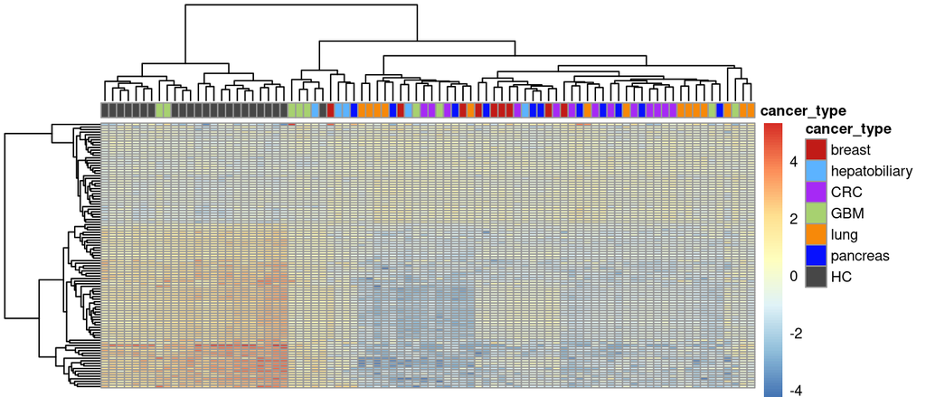

```r
# Apply variance stabilizing transformation
vst <- varianceStabilizingTransformation(dds) %>% assay()

# Filter normalized count matrix for batch 4 and differentially expressed genes
vst <- vst[gene_ids, batch_ind]
vst <- vst - rowMeans(vst)

# Data frame with metadata for the batch 4:
metadata_b4 = metadata_processed[batch_ind, ]

# Make a heat map
pheatmap(vst,
         fontsize = 8,
         show_rownames = FALSE,
         show_colnames = FALSE,
         annotation_col = dplyr::select(metadata_b4, cancer_type),
         annotation_colors = plot_colors)
```

In this heat map, samples are in columns and genes are in rows. Blue indicates genes with decreased expression, and red indicates genes with increased expression. The controls (HC) are well defined, but the GBM samples are closer to them and even mixed with them. Thus, it is likely more difficult to identify genes that will differ significantly between the GBM and controls. In addition, the cancer types are quite mixed with each other, although lung, CRC, and breast tend to cluster more.

Normalized counts of top genes overlap more in case of GBM samples for batch 4.

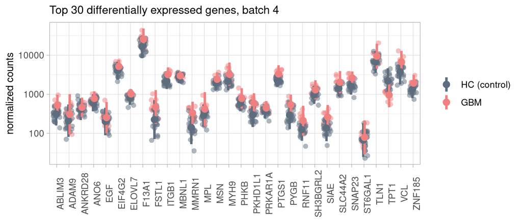

```r
# Make the normalized counts plot for GBM
DEresults_all[[which(cancer_types == "GBM")]][[3]]
```

(a better separation in normalized counts if we make the same graph for batch 2)

```r
# Summary showing the number of differentially expressed genes and the
# percentage of up- and down-regulated genes
DEresults_all[[which(cancer_types == "GBM")]][[2]][[1]]
```

[output not shown]

## Compare all results

The DEresults_all list contains results for the six cancer types. The following summary shows the percentage of genes that are up- and down-regulated. Given that we found a lot of RP (ribosomal protein) and ANKRD (ankyrin repeat domain) genes, let’s add how many of these genes are present in the top 30 results for all cancer types. We can also look at the main keywords extracted from the gene names.

```r
# Summary table
lapply(1:6, function(i){

  # The second element of the DEresults() output contains a summary of all
  # differentially expressed genes (not just the top results) that correspond to
  # results with a p-value less than 0.01.
  up = sum(DEresults_all[[i]][[2]][[2]]$up)    # number of up-regulated genes
  down = sum(DEresults_all[[i]][[2]][[2]]$down) # number of down-regulated genes
  n = up+down

  # The first element of the DEresults() output is a table with the top n
  # results, so we look at the number of RP and ANKRD genes in that table:
  ribosomal_protein = sum(str_detect(DEresults_all[[i]][[1]]$GENENAME,
                                     "ribosomal protein"),
                          na.rm = TRUE)
  ankyrin = sum(str_detect(DEresults_all[[i]][[1]]$GENENAME,
                                     "ankyrin"),
                          na.rm = TRUE)

  data.frame(cancer_type = cancer_types[i],
             up = round(100*up/n, 2),
             down = round(100*down/n, 2) ,
             ribosomal_protein = ribosomal_protein,
             ankyrin = ankyrin,
             keywords = toString(DEresults_all[[i]][[2]][[3]][1:10]))
}) %>%
  bind_rows() %>%
  print_gt()
```

| cancer_type | up | down | ribosomal_protein | ankyrin | keywords |
| --- | --- | --- | --- | --- | --- |
| breast | 8.13 | 91.87 | 3 | 3 | receptor, ankyrin, ribosomal, binding, factor, lateral, RNA, splicing, stalk, adenocarcinoma |
| hepatobiliary | 11.45 | 88.55 | 3 | 3 | ankyrin, factor, ribosomal, receptor, splicing, arginine, ATRX, brain, C, cell |
| CRC | 8.92 | 91.08 | 15 | 3 | ribosomal, ankyrin, receptor, factor, lateral, splicing, stalk, adenocarcinoma, arginine, binding |
| GBM | 26.42 | 73.58 | 0 | 1 | factor, binding, chain, finger, kinase, LIM, phosphorylase, regulatory, acetylesterase, actin |
| lung | 9.78 | 90.22 | 18 | 1 | ribosomal, kinase, receptor, adenocarcinoma, ankyrin, binding, C, cell, desmosome, DNA |
| pancreas | 9.21 | 90.79 | 14 | 3 | ribosomal, receptor, ankyrin, factor, lateral, splicing, stalk, adenocarcinoma, arginine, binding |

Most of the differentially expressed genes found in this analysis are down-regulated. For CRC, lung and pancreas, about half of the genes in the top results are RP genes.

Some top differentially expressed genes are found in more than one cancer type. Let’s look at genes that are common to 4 or more types of cancer.

```r
# Calculate the frequency of occurrence of the top genes in all types of cancer:
gene_by_ct <- sapply(1:6, function(i){

  # Ensembl IDs (ENSEMBL) for top genes are in 'gene_ids'
  sapply(gene_ids, function(j){
    as.numeric(j %in% DEresults_all[[i]][[1]]$ENSEMBL  )
  })
}) %>% as.data.frame()

# The row sums shows how many times each gene from the 'gene_ids' vector occurred
# across all cancer types
rs <- rowSums(gene_by_ct)

# Add column names to 'gene_by_ct': order of cancer_type in 'DEresults_all' is
# same as in 'cancer_types' defined above
colnames(gene_by_ct) <- cancer_types

gene_by_ct$rs <- rs  # add row sums variable

gene_by_ct$ENSEMBL <- rownames(gene_by_ct) # add ENSEMBL variable

# Annotation data for Ensembl identifiers in res_CRC
ann_data <- AnnotationDbi::select(org.Hs.eg.db,
                                  keys = gene_by_ct$ENSEMBL,
                                  # columns from org.Hs.eg.db:
                                  columns = c("SYMBOL", "GENENAME", "GENETYPE" ),
                                  keytype = "ENSEMBL") %>%
  distinct(ENSEMBL, .keep_all = TRUE)  # keep the first match for Ensembl ID

gene_by_ct <- gene_by_ct %>%    # add symbol, gene name and gene type to 'gene_by_ct'
  left_join(ann_data, by = "ENSEMBL") %>%
  # if SYMBOL is missing, replace it with ANSEMBL
  mutate(SYMBOL = ifelse(is.na(SYMBOL), ENSEMBL, SYMBOL))
```

The following table shows that GBM has only one gene in common with other cancer types, while the other 5 cancer types have many genes in common. The ANKRD and RP genes are again present in this table.

```r
gene_by_ct %>%
  filter(rs >=4) %>%  # filter genes common to at least 4 cancer types
  dplyr::select(SYMBOL,GENENAME, breast, hepatobiliary,CRC,GBM,lung, pancreas) %>%
  arrange(SYMBOL) %>%
  print_gt()
```

| SYMBOL | GENENAME | breast | hepatobiliary | CRC | GBM | lung | pancreas |
| --- | --- | --- | --- | --- | --- | --- | --- |
| ANKRD36 | ankyrin repeat domain 36 | 1 | 1 | 1 | 0 | 0 | 1 |
| ANKRD36B | ankyrin repeat domain 36B | 1 | 1 | 1 | 0 | 0 | 1 |
| ANKRD36C | ankyrin repeat domain 36C | 1 | 1 | 1 | 0 | 1 | 1 |
| GNLY | granulysin | 1 | 1 | 1 | 0 | 0 | 1 |
| IL7R | interleukin 7 receptor | 1 | 1 | 0 | 0 | 1 | 1 |
| LUC7L3 | LUC7 like 3 pre-mRNA splicing factor | 1 | 1 | 1 | 0 | 0 | 1 |
| MALAT1 | metastasis associated lung adenocarcinoma transcript 1 | 1 | 0 | 1 | 0 | 1 | 1 |
| RPLP1 | ribosomal protein lateral stalk subunit P1 | 1 | 1 | 1 | 0 | 0 | 1 |
| RPLP2 | ribosomal protein lateral stalk subunit P2 | 1 | 0 | 1 | 0 | 1 | 1 |
| RPS20 | ribosomal protein S20 | 0 | 1 | 1 | 0 | 1 | 1 |
| RPSA | ribosomal protein SA | 1 | 1 | 1 | 0 | 1 | 1 |
| SON | SON DNA and RNA binding protein | 1 | 0 | 1 | 0 | 1 | 1 |
| SRSF11 | serine and arginine rich splicing factor 11 | 1 | 1 | 1 | 0 | 0 | 1 |
| TPT1 | tumor protein, translationally-controlled 1 | 1 | 1 | 1 | 1 | 0 | 1 |
| TRBC2 | T cell receptor beta constant 2 | 1 | 1 | 1 | 0 | 1 | 1 |

The following genes appeared only for one cancer type:

```r
sapply(1:6, function(i){
  genes = gene_by_ct$SYMBOL[which(gene_by_ct$rs == 1 & gene_by_ct[, i] == 1)]
  paste(cancer_types[i], ": ", toString(sort(genes)), sep = "")
})
```

```
## [1] "breast: CD247, CD3G, DDX17, ENSG00000163386, FCMR, IFI27, ITSN2, NOTCH2, RNPC3, SRRM2, TTC3, TTN"
## [2] "hepatobiliary: ATRX, BEX3, CD8B, ENSG00000228651, ENSG00000257267, H3-3A, HNRNPA3, LDHB, SERF2, SVIP, TIMP1, TRAPPC1, UBB, VPS13C, ZRANB2"
## [3] "CRC: ENSG00000117289, RPL37A"
## [4] "GBM: ABLIM3, ADAM9, ANKRD28, ANO6, EGF, EIF4G2, ELOVL7, F13A1, FSTL1, ITGB1, MBNL1, MMRN1, MPL, MSN, MYH9, PHKB, PKHD1L1, PRKAR1A, PTGS1, PYGB, RNF11, SH3BGRL2, SIAE, SLC44A2, SNAP23, ST6GAL1, TLN1, VCL, ZNF185"
## [5] "lung: MAP3K1, MS4A1, RPL14, RPL19, RPL21, RPL3, RPL31, RPS29, RPS3A, UTRN"
## [6] "pancreas: CD3E, NOSIP, RPS8"
```

Let’s plot a correlation heat map for gene_by_ct (the distribution of the top 103 genes across all cancer_type groups) and add the number of common genes.

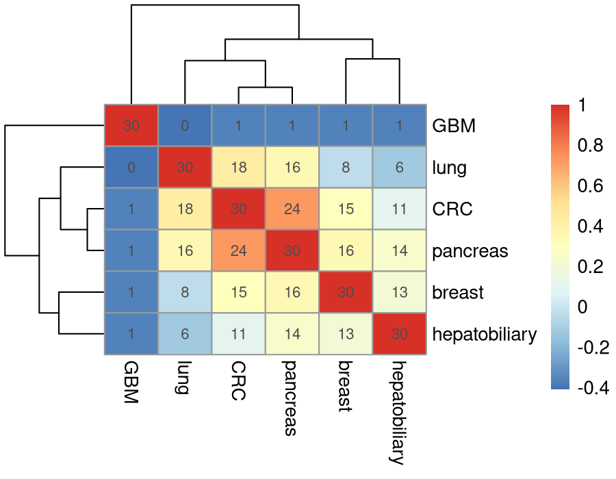

```r
# Get numeric columns from 'gene_by_ct' and convert them to matrix
n_common_genes <- as.matrix(gene_by_ct[ , 1:6] == 1)

# Determine the number of common genes across all cancer types (from top 30
# results)
n_common_genes <- crossprod(n_common_genes)

# Create heat map
pheatmap(cor(gene_by_ct[,1:6]),
         display_numbers = n_common_genes )
```

In terms of gene expression, these data suggest that the pancreas and CRC samples are similar and GBM is the least similar to other cancer types in this dataset.

We can set ‘level.1’ to another cancer type and compare the normalized counts for two cancer types.

The following graph shows that there are very few differentially expressed genes for CRC and pancreas and the counts overlap.

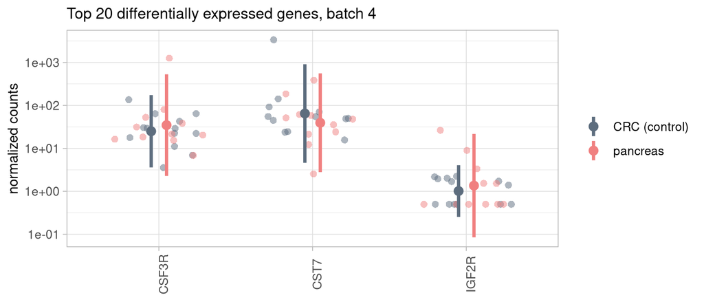

```r
# alpha set to 0.05 to find more genes
DEresults_CRC_panc <- DEresults(de = de,
                                md = metadata_processed ,
                                level.1 = "CRC",
                                level.2 = "pancreas",
                                alpha = 0.05,
                                sort.by = "log2FoldChange",
                                batch = 4,
                                n = 20 )
DEresults_CRC_panc[[3]]
```

We can get better results for hepatobiliary and lung because there are much fewer common differentially expressed genes.

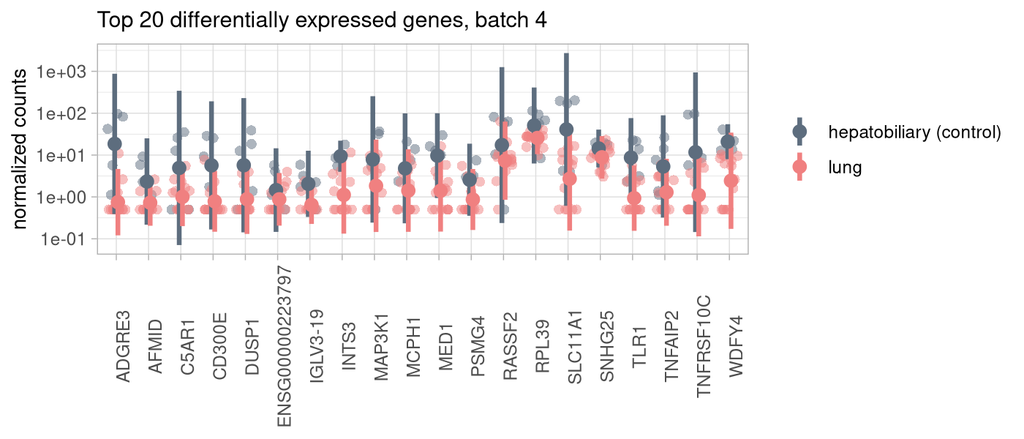

```r
DEresults_hep_lung <- DEresults(de = de,
                                  md = metadata_processed ,
                                  level.1 = "hepatobiliary",
                                  level.2 = "lung",
                                  alpha = 0.01,
                                  sort.by = "log2FoldChange",
                                  batch = 4,
                                  n = 20 )

DEresults_hep_lung[[3]]
```

# Summary

The GSE68086 datasets contain counts of RNA reads for 285 samples and 57,736 genes. These data are from a high-throughput sequencing experiment and include 55 samples from healthy individuals (HC, control group) and 228 samples from patients with six different cancer types: lung cancer, colorectal cancer, pancreatic cancer, breast cancer, glioblastoma, and hepatobiliary carcinoma.

• The main variables that can be extracted from the raw metadata file are batch number (batch), cancer type (cancer_type), and mutation subclass (mutational_subclass).

◦ All samples were obtained in 6 batches, however only batches 2, 3 and 4 are present in the control group (HC).

◦ During the cleaning/filtering process, 53 samples were discarded, including two samples with low reads counts, samples that were less correlated within their cancer_type group, and batches 1, 5, and 6.

• The counts_matrix that was used as input to the DESeq() function contained the raw counts of RNA sequencing reads corresponding to 57,736 genes and 232 samples.

◦ About 50% of these genes have 0 raw counts.

◦ Before applying unsupervised machine learning methods, count normalization and a variance stabilizing transformation were applied (DESeq2 vst() function was used for the entire dataset and varianceStabilizingTransformation() for a subset).

• Surrogate variable analysis (SVA) and Principal component analysis (PCA) showed the presence of the batch effect.

• Differential gene expression analysis was performed using the DESeq() function, and the ‘betaPrior’ argument was set to TRUE to obtain shrunken estimates. The design formula included batch, mutational_subclass and cancer_type.

• The results were extracted using the results() function and the DEresults() user function.

◦ We observe an increase in the proportion of protein-coding genes among differentially expressed genes.

◦ For all cancer types, there are more down-regulated genes than up-regulated genes, but for GBM this difference is smaller than for the other 5 cancer types in this dataset.

◦ If we take the 30 genes with the highest differential expression for each cancer type, we get a total of 103 unique genes, since there are genes that are common to at least two cancer types.

◦ For CRC, lung and pancreas, about half of the genes in the top results are ribosomal protein genes.

◦ In the top results for CRC and pancreas, 24 out of 30 genes are the same, indicating similar gene expression profiles for these cancer types. PCA plots also indicate similarities between CRC and pancreas samples.

◦ Gene expression in GBM samples differed least from control samples among all cancer types in this dataset.

# References

(1)

Li, M.; Sun, Q.; Wang, X. Transcriptional Landscape of Human Cancers. *Oncotarget* **2017**, *8* (21), 34534–34551. https://doi.org/10.18632/oncotarget.15837.

(2)

Xu, H.; Ma, Y.; Zhang, J.; Gu, J.; Jing, X.; Lu, S.; Fu, S.; Huo, J. Identification and Verification of Core Genes in Colorectal Cancer. *BioMed Research International* **2020**, *2020* (1), 8082697. https://doi.org/10.1155/2020/8082697.

(3)

Hu, H.; He, J.; Zhao, H. Construction and Validation of a Diagnostic Model for Cholangiocarcinoma Based on Tumor-Educated Platelet RNA Expression Profiles. *Oncologie* **2025**, *27* (2), 277–293. https://doi.org/10.1515/oncologie-2024-0520.

(4)

Ge, X.; Yuan, L.; Cheng, B.; Dai, K. Identification of Seven Tumor-Educated Platelets RNAs for Cancer Diagnosis. *Journal of Clinical Laboratory Analysis* **2021**, *35* (6), e23791. https://doi.org/10.1002/jcla.23791.

(5)

Best, M. G.; Sol, N.; Kooi, I.; Tannous, J.; Westerman, B. A.; Rustenburg, F.; Schellen, P.; Verschueren, H.; Post, E.; Koster, J.; Ylstra, B.; Ameziane, N.; Dorsman, J.; Smit, E. F.; Verheul, H. M.; Noske, D. P.; Reijneveld, J. C.; Nilsson, R. J. A.; Tannous, B. A.; Wesseling, P.; Wurdinger, T. RNA-Seq of Tumor-Educated Platelets Enables Blood-Based Pan-Cancer, Multiclass, and Molecular Pathway Cancer Diagnostics. *Cancer Cell* **2015**, *28* (5), 666–676. https://doi.org/10.1016/j.ccell.2015.09.018.

(6)

Wang, L.; Felts, S. J.; Van Keulen, V. P.; Pease, L. R.; Zhang, Y. Exploring the Effect of Library Preparation on RNA Sequencing Experiments. *Genomics* **2019**, *111* (6), 1752–1759. https://doi.org/10.1016/j.ygeno.2018.11.030.

(7)

Evans, C.; Hardin, J.; Stoebel, D. M. Selecting Between-Sample RNA-Seq Normalization Methods from the Perspective of Their Assumptions. *Briefings in Bioinformatics* **2017**, *19* (5), 776–792. https://doi.org/10.1093/bib/bbx008.

(8)

Leek, J. D., Jeffrey T AND Storey. Capturing Heterogeneity in Gene Expression Studies by Surrogate Variable Analysis. *PLOS Genetics* **2007**, *3* (9), 1–12. https://doi.org/10.1371/journal.pgen.0030161.

(9)

Love, M. I.; Anders, S.; Huber, W. Analyzing RNA-Seq Data with DESeq2, 2025.

(10)

Love, M. I.; Huber, W.; Anders, S. Moderated Estimation of Fold Change and Dispersion for RNA-Seq Data with DESeq2. *Genome Biology* **2014**, *15* (12), 550. https://doi.org/10.1186/s13059-014-0550-8.

(11)

Danielsson, F.; Skogs, M.; Huss, M.; Rexhepaj, E.; O’Hurley, G.; Klevebring, D.; Pontén, F.; Gad, A. K. B.; Uhlén, M.; Lundberg, E. Majority of Differentially Expressed Genes Are down-Regulated During Malignant Transformation in a Four-Stage Model. *Proceedings of the National Academy of Sciences* **2013**, *110* (17), 6853–6858. https://doi.org/10.1073/pnas.1216436110.

(12)

Long, T.; Liu, Z.; Zhou, X.; Yu, S.; Tian, H.; Bao, Y. Identification of Differentially Expressed Genes and Enriched Pathways in Lung Cancer Using Bioinformatics. *Molecular Medicine Reports* **2019**, *19* (3), 2029–2040. https://doi.org/10.3892/mmr.2019.9878.

(13)

Jing, X. Ribosomal Proteins and Colorectal Cancer. *Current Genomics* **2007**, *8* (1), 43–49. https://doi.org/10.2174/138920207780076938.

(14)

Cao, J.; Cai, X.; Zheng, L.; Geng, L.; Shi, Z.; Pao, C. C.; Zheng, S. Characterization of Colorectal-Cancer-Related cDNA Clones Obtained by Subtractive Hybridization Screening. *Journal of Cancer Research and Clinical Oncology* **1997**, *123* (8), 447–451. https://doi.org/10.1007/BF01372549.

(15)

Bertucci, F.; Salas, S.; Eysteries, S.; Nasser, V.; Finetti, P.; Ginestier, C.; Charafe-Jauffret, E.; Loriod, B.; Bachelart, L.; Montfort, J.; Victorero, G.; Viret, F.; Ollendorff, V.; Fert, V.; Giovaninni, M.; Delpero, J.-R.; Nguyen, C.; Viens, P.; Monges, G.; Birnbaum, D.; Houlgatte, R. Gene Expression Profiling of Colon Cancer by DNA Microarrays and Correlation with Histoclinical Parameters. *Oncogene* **2004**, *23* (7), 1377–1391. https://doi.org/10.1038/sj.onc.1207262.

(16)

Bai, R.; Li, D.; Shi, Z.; Fang, X.; Ge, W.; Zheng, S. Clinical Significance of Ankyrin Repeat Domain 12 Expression in Colorectal Cancer. *Journal of Experimental & Clinical Cancer Research* **2013**, *32* (1), 35. https://doi.org/10.1186/1756-9966-32-35.

# sessionInfo

**R version** 4.4.3 (2025-02-28)

**Attached base packages**:

| stats4 | stats | graphics |
| --- | --- | --- |
| grDevices | utils | methods |
| base |  |  |

**Other attached packages**:

| org.Hs.eg.db_3.20.0 | AnnotationDbi_1.68.0 | tidyr_1.3.1 |
| --- | --- | --- |
| DESeq2_1.46.0 | SummarizedExperiment_1.36.0 | MatrixGenerics_1.18.1 |
| matrixStats_1.5.0 | GenomicRanges_1.58.0 | GenomeInfoDb_1.42.3 |
| IRanges_2.40.1 | S4Vectors_0.44.0 | sva_3.54.0 |
| BiocParallel_1.40.2 | genefilter_1.88.0 | mgcv_1.9-3 |
| nlme_3.1-168 | patchwork_1.3.1 | gt_1.0.0 |
| vsn_3.74.0 | Biobase_2.66.0 | BiocGenerics_0.52.0 |
| pheatmap_1.0.13 | ggplot2_3.5.1 | stringr_1.5.1 |
| dplyr_1.1.4.9000 | knitr_1.49 | markdown_2.0 |
| here_1.0.1 |  |  |